# Assignment8

Luke Van Horn

1/26/2023

## Code Reflection

1. Go through your recent assignments and the posted solutions (Assignment 6 posted solutions and Weekly Assignment 2 solutions) - compare your code to the posted code.
- Can you run your simulated data function with new values for the means? If not, what do you need to change about your code?
- Are there differences between the posted code and yours? Did you notice you were missing anything?
- Make sure you annotate your code using # and leave brief descriptions of your thought process.

### Assignment 6

1. Examine the structure of the iris data set. How many observations and variables are in the data set?

```r
library(tidyverse)
str(iris)
```

```
## 'data.frame':    150 obs. of  5 variables:
##  $ Sepal.Length: num  5.1 4.9 4.7 4.6 5 5.4 4.6 5 4.4 4.9 ...
##  $ Sepal.Width : num  3.5 3 3.2 3.1 3.6 3.9 3.4 3.4 2.9 3.1 ...
##  $ Petal.Length: num  1.4 1.4 1.3 1.5 1.4 1.7 1.4 1.5 1.4 1.5 ...
##  $ Petal.Width : num  0.2 0.2 0.2 0.2 0.2 0.4 0.3 0.2 0.2 0.1 ...
##  $ Species     : Factor w/ 3 levels "setosa","versicolor",..: 1 1 1 1 1 1 1 1 1 1 ...
```

```r
glimpse(iris) # code looks fine
```

```
## Rows: 150
## Columns: 5
## $ Sepal.Length <dbl> 5.1, 4.9, 4.7, 4.6, 5.0, 5.4, 4.6, 5.0, 4.4, 4.9, 5.4, 4.…
## $ Sepal.Width  <dbl> 3.5, 3.0, 3.2, 3.1, 3.6, 3.9, 3.4, 3.4, 2.9, 3.1, 3.7, 3.…
## $ Petal.Length <dbl> 1.4, 1.4, 1.3, 1.5, 1.4, 1.7, 1.4, 1.5, 1.4, 1.5, 1.5, 1.…
## $ Petal.Width  <dbl> 0.2, 0.2, 0.2, 0.2, 0.2, 0.4, 0.3, 0.2, 0.2, 0.1, 0.2, 0.…
## $ Species      <fct> setosa, setosa, setosa, setosa, setosa, setosa, setosa, s…
```

2. Create a new data frame iris1 that contains only the species virginica and versicolor with sepal lengths longer than 6 cm and sepal widths longer than 2.5 cm. How many observations and variables are in the data set?

```r
iris1<-filter(iris, Species == "virginica" | Species =="versicolor" , Sepal.Length > 6 & Sepal.Width > 2.5) # or section could be written as Species %in% c("virginica", "versicolor")
glimpse(iris1)
```

```
## Rows: 56
## Columns: 5
## $ Sepal.Length <dbl> 7.0, 6.4, 6.9, 6.5, 6.3, 6.6, 6.1, 6.7, 6.1, 6.1, 6.4, 6.…
## $ Sepal.Width  <dbl> 3.2, 3.2, 3.1, 2.8, 3.3, 2.9, 2.9, 3.1, 2.8, 2.8, 2.9, 3.…
## $ Petal.Length <dbl> 4.7, 4.5, 4.9, 4.6, 4.7, 4.6, 4.7, 4.4, 4.0, 4.7, 4.3, 4.…
## $ Petal.Width  <dbl> 1.4, 1.5, 1.5, 1.5, 1.6, 1.3, 1.4, 1.4, 1.3, 1.2, 1.3, 1.…
## $ Species      <fct> versicolor, versicolor, versicolor, versicolor, versicolo…
```

3. Now, create a iris2 data frame from iris1 that contains only the columns for Species, Sepal.Length, and Sepal.Width. How many observations and variables are in the data set?

```r
iris2<-select(iris1, Species, Sepal.Length, Sepal.Width)
glimpse(iris2) # looks good
```

```
## Rows: 56
## Columns: 3
## $ Species      <fct> versicolor, versicolor, versicolor, versicolor, versicolo…
## $ Sepal.Length <dbl> 7.0, 6.4, 6.9, 6.5, 6.3, 6.6, 6.1, 6.7, 6.1, 6.1, 6.4, 6.…
## $ Sepal.Width  <dbl> 3.2, 3.2, 3.1, 2.8, 3.3, 2.9, 2.9, 3.1, 2.8, 2.8, 2.9, 3.…
```

4. Create an iris3 data frame from iris2 that orders the observations from largest to smallest sepal length. Show the first 6 rows of this data set.

```r
iris3<-arrange(iris2, by=desc(Sepal.Length)) # "by=" is unnecessary
head(iris3)
```

```
##     Species Sepal.Length Sepal.Width
## 1 virginica          7.9         3.8
## 2 virginica          7.7         3.8
## 3 virginica          7.7         2.6
## 4 virginica          7.7         2.8
## 5 virginica          7.7         3.0
## 6 virginica          7.6         3.0
```

5. Create an iris4 data frame from iris3 that creates a column with a sepal area (length * width) value for each observation. How many observations and variables are in the data set?

```r
iris4<-mutate(iris3, Sepal.Area = Sepal.Length*Sepal.Width)
glimpse(iris4)
```

```
## Rows: 56
## Columns: 4
## $ Species      <fct> virginica, virginica, virginica, virginica, virginica, vi…
## $ Sepal.Length <dbl> 7.9, 7.7, 7.7, 7.7, 7.7, 7.6, 7.4, 7.3, 7.2, 7.2, 7.2, 7.…
## $ Sepal.Width  <dbl> 3.8, 3.8, 2.6, 2.8, 3.0, 3.0, 2.8, 2.9, 3.6, 3.2, 3.0, 3.…
## $ Sepal.Area   <dbl> 30.02, 29.26, 20.02, 21.56, 23.10, 22.80, 20.72, 21.17, 2…
```

```r
# looks good
```

6. Create the variable irisTab that shows the average sepal length, the average sepal width, and the sample size of the entire iris4 data frame and print irisTab.

```r
irisTab<- summarize(iris4,mean(Sepal.Length), mean(Sepal.Width), TotalNumber = n())
print(irisTab) # didn't define variables. It still works but I would have to write Var= in front of each function to name the variables.
```

```
##   mean(Sepal.Length) mean(Sepal.Width) TotalNumber
## 1           6.698214          3.041071          56
```

7. Finally, create iris5 that calculates the average sepal length, the average sepal width, and the sample size for each species of in the iris4 data frame and print iris5.

```r
irisSpecies <- group_by(iris4, Species)
iris5<-summarize(irisSpecies, mean(Sepal.Length), mean(Sepal.Width), TotalNumber = n())
print(iris5) # looks good, again see above comment for variable names
```

```
## # A tibble: 2 × 4
##   Species    `mean(Sepal.Length)` `mean(Sepal.Width)` TotalNumber
##   <fct>                     <dbl>               <dbl>       <int>
## 1 versicolor                 6.48                2.99          17
## 2 virginica                  6.79                3.06          39
```

8. In these exercises, you have successively modified different versions of the data frame iris1 iris2 iris3 iris4 iris5. At each stage, the output data frame from one operation serves as the input fro the next. A more efficient way to do this is to use the pipe operator %>% from the tidyr package. Rework all of your previous statements (except for irisTab) into an extended piping operation that uses iris as the input and generates irisFinal as the output.

```r
irisfinal<-iris%>%
  filter(Species == "virginica" | Species =="versicolor" , Sepal.Length > 6 & Sepal.Width > 2.5)%>%
  select(Species, Sepal.Length, Sepal.Width)%>%
  arrange(by=desc(Sepal.Length))%>%
  mutate(Sepal.Area = Sepal.Length*Sepal.Width)%>%
  group_by(Species)%>%
  summarize(mean(Sepal.Length), mean(Sepal.Width), TotalNumber = n())
print(irisfinal)
```

```
## # A tibble: 2 × 4
##   Species    `mean(Sepal.Length)` `mean(Sepal.Width)` TotalNumber
##   <fct>                     <dbl>               <dbl>       <int>
## 1 versicolor                 6.48                2.99          17
## 2 virginica                  6.79                3.06          39
```

### Weekly Assignment 2

1. Create a function that returns a data frame with 2 columns (named “Type” and “Value”) and 50 rows/observations.
- The first column should have “Control” as the first 25 observations and “Treatment” as the second half of observations.
- The second column should have the first 25 values as random and normally distributed with a mean of 10 and standard deviation of 1.5. The next 25 values of the second column should be random and normally distributed with a mean of 45 and standard deviation of 2.
- You can do this all as a single line of code in the function or by breaking it up into multiple code blocks.

```r
#########################
# FUNCTION: funky
# generates data frame
# input: null
# outputs: data frame
funky<-function(p=NULL){
  if(is.null(p)) {
    Type<-c(rep("Control", 25), rep("Treatment", 25))
    Value<-c(rnorm(25, mean=10, sd=1.5),rnorm(25, mean=45, sd=2))
    p<-data.frame(Type,Value)

  }
  return(p)
}
# I don't have a set seed so this will be different every time I run it. I could have set the defaults as generating the data frame. That would mean I could run the function with variable arguments instead of specific numbers which would make it reproducible. Substitute 25 for n, enter default variables in function in place of specific numbers.
#it might look like this
set.seed(12)
funky<-function(m1=10, sd1=1.5, m2=45, sd2=2, n=25){
    Type<-c(rep("Control", n), rep("Treatment", n))
    Value<-c(rnorm(n, mean=m1, sd=sd1),rnorm(n, mean=m2, sd=sd2))
    p<-data.frame(Type,Value)
    return(p)
  }
```

Question 2. Save your new function’s output as a variable, and use a function to view the first 6 rows of the data frame.

```r
funk<-funky()
head(funk)
```

```
##      Type     Value
## 1 Control  7.779149
## 2 Control 12.365754
## 3 Control  8.564883
## 4 Control  8.619992
## 5 Control  7.003537
## 6 Control  9.591556
```

Question 3. Let’s say you would like to know whether there is a statistically significant difference in “Value” (response variable y) depending on “Type” (explanatory variable x). Type ?aov in the console to determine how to run an analysis of variance (ANOVA) on your simulated data. Write a line of code that displays a summary of your ANOVA.

```r
aovfunk<-aov(Value~Type, data=funky())
summary(aovfunk)
```

```
##             Df Sum Sq Mean Sq F value Pr(>F)
## Type         1  15304   15304    4162 <2e-16 ***
## Residuals   48    176       4
## ---
## Signif. codes:  0 '***' 0.001 '**' 0.01 '*' 0.05 '.' 0.1 ' ' 1
```

Question 4. Finally create a function that uses a data frame as its input and returns only the p-value of an ANOVA summary table (feel free to use Google/Stack Overflow). Write your code in such a way that you can use any simulated data set with two columns as the function’s argument.

```r
#############################
# FUNCTION: fresh
# finds the p-value of a data frame
# input: data frame as a variable
# outputs: p-value

fresh<-function(p=funk){
  aovfunk<-aov(Value~Type, data=funk)
  pval<-summary(aovfunk)[[1]][["Pr(>F)"]][1]
  return(pval)
}
fresh(funk)
```

```
## [1] 2.215302e-53
```

## Code Annotation

I used dryad data to reconstruct a publication-quality figure. Copy my code into an Rmd file and annotate what each ggplot line of code is doing, including any arguments. You can use a combination of googling and ‘trial/error coding:’ change the arguments/options to visually see how it affects the plot.

```r
library(tidyverse) #library: loading tidyverse
library(ggthemes) #library: loading ggthemes


# Data obtained from Veysey Powell and Babbitt 2016: An experimental test of buffer utility as a technique for managing pool-breeding amphibians https://datadryad.org/stash/dataset/doi:10.5061%2Fdryad.547rp

dryadData <- read.table(file="Amphibian-Data/veysey powell and babbitt_data_buffers and amphibians2.csv", header=TRUE, sep=",", stringsAsFactors = TRUE) # creating a variable that consists of the dataset. Header= TRUE, means that the first line in the dataset is the name of the variables. sep means a comma is what separates values on each line. stringsAsFactors

dryadData$treatment
```

```
##   [1] 30m       30m       30m       30m       30m       30m       30m
##   [8] 30m       30m       30m       30m       30m       30m       30m
##  [15] 30m       30m       30m       30m       100m      100m      100m
##  [22] 100m      100m      100m      Reference Reference Reference Reference
##  [29] Reference Reference 100m      100m      100m      100m      100m
##  [36] 100m      100m      100m      100m      100m      100m      100m
##  [43] 30m       30m       30m       30m       30m       30m       Reference
##  [50] Reference Reference Reference Reference Reference 100m      100m
##  [57] 100m      100m      100m      100m      Reference Reference Reference
##  [64] Reference Reference Reference 30m       30m       30m       30m
##  [71] 30m       30m       30m       30m       30m       30m       30m
##  [78] 30m       30m       30m       30m       30m       30m       30m
##  [85] 100m      100m      100m      100m      100m      100m      Reference
##  [92] Reference Reference Reference Reference Reference 100m      100m
##  [99] 100m      100m      100m      100m      100m      100m      100m
## [106] 100m      100m      100m      30m       30m       30m       30m
## [113] 30m       30m       Reference Reference Reference Reference Reference
## [120] Reference 100m      100m      100m      100m      100m      100m
## [127] Reference Reference Reference Reference Reference Reference
## Levels: 100m 30m Reference
```

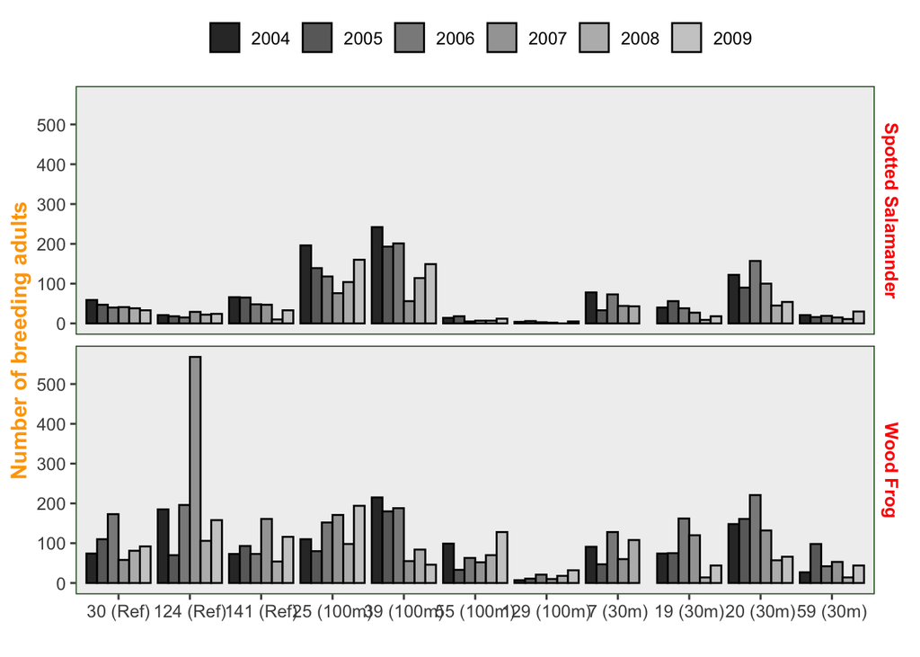

```r
# glimpse(dryadData)
# head(dryadData)
# table(dryadData$species)

dryadData$species<-factor(dryadData$species, labels=c("Spotted Salamander", "Wood Frog")) #creating y 'labels' to use for the plot instead of AMMA and RASY

#class(dryadData$treatment)
dryadData$treatment <- factor(dryadData$treatment,
            levels=c("Reference",
                     "100m", "30m")) #changes the order of the treatment groups to reference, 100m, 30m instead of 100m, 30m, reference


p<- ggplot(data=dryadData, #defines the data set that the plot will be made from
       aes(x=interaction(wetland, treatment),
           y=count.total.adults, fill=factor(year))) + geom_bar(position="dodge", stat="identity", color="black") + # defines which columns and rows should be represented in the plot on the x and y axes. interaction groups treatment and wetland. fill groups and colors columns by year. geom_bar makes it a bar plot. position defines where the bars should be such as stacked or grouped. Stat is how the plot treats the data. color changes the color of the outlines.
  ylab("Number of breeding adults") + #gives the y axis title
  xlab("") + # gives the x axis title (nothing)
  scale_y_continuous(breaks = c(0,100,200,300,400,500)) + # labels the units of the y axis and makes them continuous on a defined range
  scale_x_discrete(labels=c("30 (Ref)", "124 (Ref)", "141 (Ref)", "25 (100m)","39 (100m)","55 (100m)","129 (100m)", "7 (30m)","19 (30m)","20 (30m)","59 (30m)")) + #labels the units for the x axis. Makes them discrete values
  facet_wrap(~species, nrow=2, strip.position="right") + # wraps the plots into a more easily viewed double plot. species names are placed on the right
  theme_few() + scale_fill_grey() + # makes the theme and makes it greyscale
  theme(panel.background = element_rect(fill = 'gray94', color = 'green'), legend.position="top",  legend.title= element_blank(), axis.title.y = element_text(size=12, face="bold", colour = "orange"), strip.text.y = element_text(size = 10, face="bold", colour = "red"))+  # changes the color and fill of the panel background's rectangle, locates the position of the legend, removes a legend title, defines the size, boldness, and color of the y axis label. strip.text.y changes the size, boldness, and color of the species name on the y axis on the right
  guides(fill=guide_legend(nrow=1,byrow=TRUE)) # makes the legends one row instead of two

p
```